# Practice Quiz 6: Regression Inference + Trees

MSE 125 — Lectures 12–13

Use this practice quiz to prepare for Quiz 6 (Wednesday, May 13). The real quiz will have 2 questions in 10 minutes, closed-book. This practice set has 11 questions covering Lectures 12–13: reading a regression output table, conditional null hypothesis, confidence intervals on coefficients, **statistical vs. practical significance**, residual diagnostics and the LINE conditions, logistic regression and odds ratios, decision tree splitting (Gini impurity) and overfitting, random forests (bagging + feature subsampling), the no-U-curve in `n_estimators`, trees vs. linear geometry, feature importance, and the forest’s extrapolation failure outside the training range.

Every concept tested on the real quiz appears somewhere on this practice set, with a different scenario.

**Question 1.** A coffee chain regresses **monthly revenue per location** (in $1,000s) on `has_drive_through`, `store_sqft`, `traffic_count`, and `neighborhood_median_income`. The fitted coefficient on `has_drive_through` is **$4,200/month** with 95% CI [$2,800, $5,600]. An earlier model **without** `neighborhood_median_income` reported `has_drive_through` $\approx$ **$7,500/month**.

1. Interpret the current `has_drive_through` coefficient ($4,200) in plain English in 1–2 sentences. Reference what “controlling for” means here.
2. Why did the `has_drive_through` coefficient **shrink** from $7,500 to $4,200 when `neighborhood_median_income` was added? Reference the **conditional null** in 2 sentences.

**TipSolution**

**(a)** **Holding `store_sqft`, `traffic_count`, and `neighborhood_median_income` fixed**, locations with a drive-through earn on average about **$4,200/month more** than locations without one (the 95% CI suggests the true premium is plausibly between $2,800 and $5,600/month).

**(b)** The hypothesis test for `has_drive_through` is **conditional on the other predictors in the model**: it asks whether the drive-through adds anything *beyond what the other predictors already explain*. Drive-through locations tend to be in higher-income neighborhoods (more car traffic, suburban demographics), so the original $7,500 coefficient was picking up some of the income effect; adding `neighborhood_median_income` to the model attributes that income-related signal to the income variable, and the drive-through coefficient shrinks to the part attributable to the drive-through *given* the same neighborhood income. Same predictor, different conditional null.

**Question 2.** A fitness app runs an A/B test on a new daily-streak notification feature with **800,000 users per arm**. They fit a regression of **minutes/day in app** on `has_notification` and user controls. Output:

| predictor | coef | std err | t | P>\|t\| | [0.025, 0.975] |
| --- | --- | --- | --- | --- | --- |
| has_notification[T.Yes] | 0.60 | 0.10 | 6.0 | <0.001 | [0.40, 0.80] |
| (other controls) | … | … | … | … | … |

Mean daily app use: **18 min**. SD: **22 min**.

1. Compute the **standardized effect size** (also called Cohen’s d): coef ÷ SD of outcome. Is the effect **practically meaningful at the per-user level**? (1–2 sentences.)
2. **Scale the CI to a year.** Translate the 95% CI [0.40, 0.80] from per-user-per-day minutes into a **per-user-per-year** range (use 365 days). Then translate it to a **fleet-wide annual** range across all 8M users on the platform.
3. The PM declares “$p < 0.001$, ship it.” Give your recommendation in 2–3 sentences. Reference the standardized effect size from (a), the per-user-per-year range from (b), and one practical consideration (cost / opportunity cost / notification fatigue).

**TipSolution**

**(a)** Standardized effect size (Cohen’s d) = $0.60 / 22 \approx \mathbf{0.027}$ — roughly **3% of an SD**. This is far below Cohen’s “small” benchmark of 0.2; the per-user effect is about 36 extra seconds/day on an 18-min baseline. **Not practically meaningful at the per-user level.**

**(b)** Per-user-per-year: $[0.40, 0.80]$ min/day $\times 365 = \mathbf{[146, 292]}$ minutes/year per user (about 2.4 to 4.9 extra hours/year per user). Fleet-wide ($\times 8,000,000$ users): $\mathbf{[1.17, 2.34]}$ **billion** extra minutes/year (about $1.95 \times 10^7$ to $3.9 \times 10^7$ user-hours/year). The CI excludes 0 throughout, but the per-user range is small while the fleet-wide range is huge — exactly the gap between per-unit standardized effect size and aggregate impact at scale.

**(c)** *Sample answer (either side defensible):* The standardized effect size ($\approx 0.03$) is in the noise-level range and no individual user will notice 36 extra seconds/day. But scaled across 8M users, the fleet-wide annual gain ($\sim$ 2 billion minutes from (b)) might justify the shipping cost — depending on the engineering + maintenance burden, the notification-fatigue risk (a per-user negative that the regression didn’t measure), and what other interventions are on the roadmap. **Either ship-or-don’t earns full credit with a calculation tying the standardized effect *and* the fleet-wide aggregate to a stated trade-off.** A “ship, p < 0.001” answer that doesn’t acknowledge the per-user smallness gets no credit; a “don’t ship, standardized effect is small” answer that ignores aggregate scale also gets no credit.

This is the lesson from the chapter: **statistical significance is no substitute for practical importance**, and “practical importance” depends on the *unit of analysis*. With $n$ in the hundreds of thousands, the t-test is so sensitive that any nonzero effect crosses $\alpha = 0.05$ — the decision belongs in aggregate dollars (or minutes), not in the p-value.

**Question 3.** An e-commerce team regresses **order value** on user features. The residual Q-Q plot:

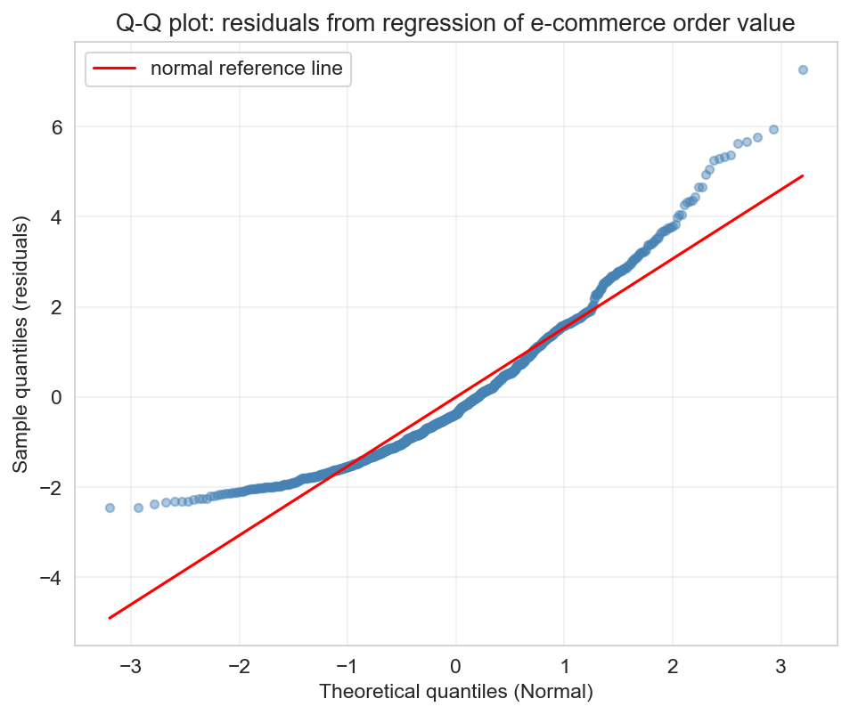

1. Which **LINE** assumption is failing? Name the shape of the residual distribution (look at which tail bows away from the diagonal). (1 sentence.)
2. The team considers log-transforming the response (`log(order_value)`). In 1–2 sentences, why might this help with the shape you identified in (a)?

**TipSolution**

**(b)** Order values have a **hard floor near $0** but a **long right tail** (most orders are small; a few are huge). The log transform compresses the right tail and stretches the left, producing residuals closer to symmetric and Normal. After log-transforming, the chapter’s diagnostic recipe (re-fit, re-plot residuals) usually shows a much cleaner Q-Q plot, and the regression’s CIs become more trustworthy.

**Question 4.** A housing analyst regresses **home price** ($1,000s) on home features. The residuals-vs-fitted plot:

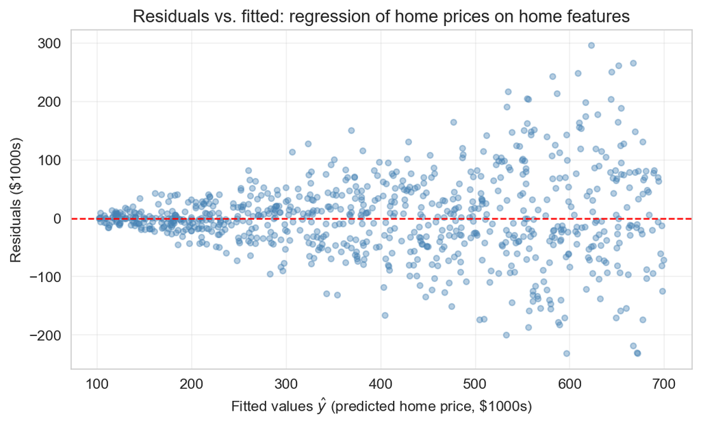

1. Which **LINE** assumption is failing? What does the fan shape mean substantively about how the model fits at low vs. high price levels? (1–2 sentences.)
2. Name **one fix** from the lecture for this issue.

**TipSolution**

**(a)** **E (equal variance)** is violated — the plot shows **heteroscedasticity** (the spread of residuals fans out as fitted price grows). Substantively, **cheap homes vary in price by a few thousand dollars; expensive homes vary by tens or hundreds of thousands**. The constant-variance assumption underlying the formula-based CIs is wrong: prediction intervals will be too wide for cheap homes and too narrow for expensive ones.

**(b)** **Log-transform the response** (fit `log(price)` instead of `price`). Log compresses high values more than low ones, so the residual variance is stabilized across fitted values. (Other accepted answers: *bootstrap CIs* — not assumption-bound; *robust SEs* — adjust the SE formula to remain valid under heteroscedasticity.)

**Question 5.** A hospital fits a logistic regression to predict 30-day readmission. The forest plot of odds ratios with 95% CIs:

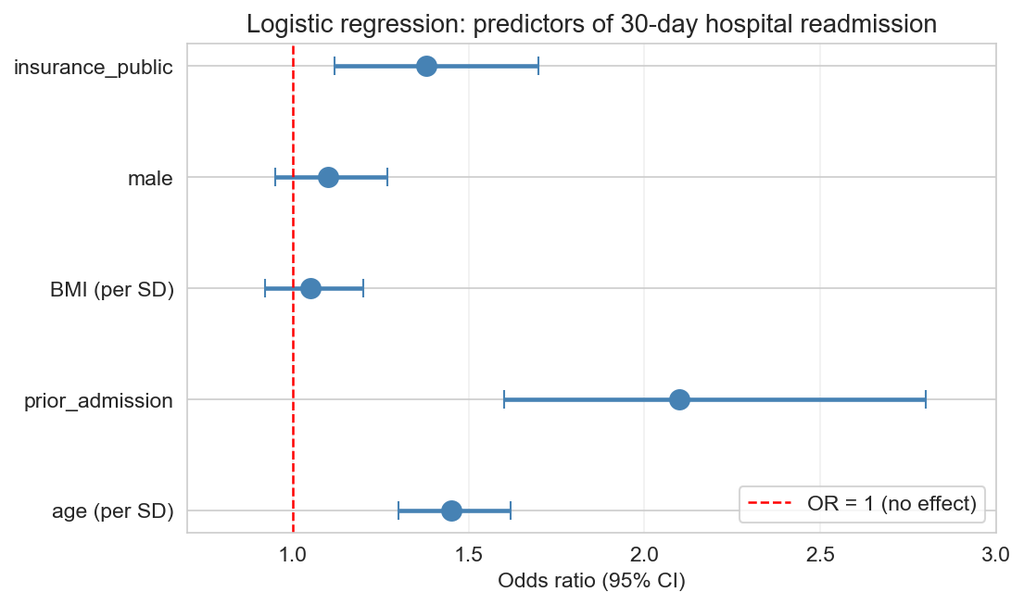

1. Which predictors are **statistically distinguishable from “no effect”** at the 95% level? What is the criterion on the CI for an odds ratio? (1–2 sentences.)
2. Interpret the **age** odds ratio in plain English. (`age` is on a per-SD scale; 1 SD of age is about 12 years in this cohort.)

**TipSolution**

**(a)** A predictor is statistically distinguishable from “no effect” if its 95% CI for the odds ratio **excludes 1** (the null value for OR; equivalent to $\beta = 0$ on the log-odds scale). From the plot:

- **age** (CI roughly [1.30, 1.62]) — significant
- **prior_admission** (CI [1.60, 2.80]) — significant
- **insurance_public** (CI [1.12, 1.70]) — significant
- **BMI** (CI [0.92, 1.20]) — NOT significant (crosses 1)
- **male** (CI [0.95, 1.27]) — NOT significant (crosses 1)

**(b)** Holding the other predictors fixed, **a one-SD increase in age (about 12 years) multiplies the odds of readmission by about 1.45** — a 45% increase in odds per 12 years of age. (Equivalently: going from age 60 to age 72 raises the odds of 30-day readmission by about 45%.)

**Question 6.** A used-car dealer fits decision trees of varying depth to predict car prices. Train and test R² as `max_depth` grows:

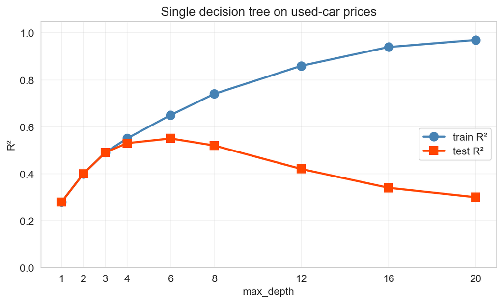

1. At `max_depth = 20`, the train R² is $\approx$ 0.97 but the test R² is $\approx$ 0.30. Name the phenomenon. In 1 sentence, what has the tree learned at depth 20?
2. A teammate proposes picking the `max_depth` that **maximizes train R²**. Why is this a bad idea? What should they do instead?

**TipSolution**

**(a)** **Overfitting**. At `max_depth = 20`, every leaf holds a tiny subset of training rows; the tree has **memorized the specific training observations and their idiosyncratic noise**, fitting the training data almost perfectly but capturing nothing that generalizes.

**(b)** Maximizing **train** R² always picks the deepest tree (more depth $\Rightarrow$ more flexibility $\Rightarrow$ more training fit), but as the test curve shows, that’s exactly the worst place to be on the test set. Instead, pick depth by **cross-validation**: sweep candidate depths, score each by 5-fold CV on the training data, pick the depth with the highest CV score. The test set stays clean for a final honest evaluation.

**Question 7.** A SaaS company fits random forests of varying size to predict customer churn:

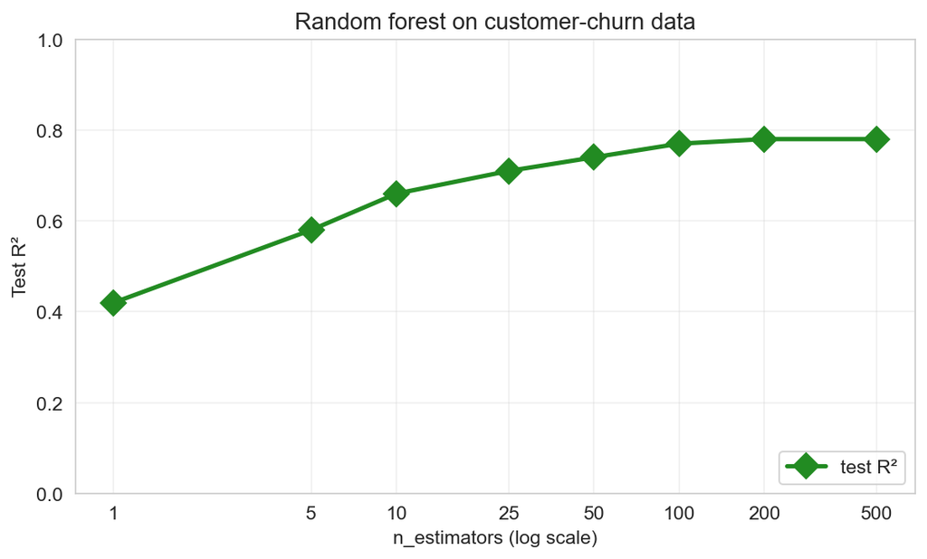

1. From the curve, what is the test R² **plateau** approximately? Name **two distinct sources of randomness** that distinguish the individual trees in a random forest from each other (i.e., what makes their predictions disagree). (1–2 sentences total.)
2. In 1–2 sentences, explain why adding more trees doesn’t push the test R² to 1.

**TipSolution**

**(a)** Plateau at test R² $\approx$ **0.78**. The two sources of randomness:

1. **Bootstrap samples of rows.** Each tree trains on a different random sample of rows (drawn with replacement from the original training data) — so each tree sees a different ~63% of distinct rows.
2. **Feature subsampling at each split.** At each internal node, the tree considers only a random subset of features when picking the best split — forcing trees to find different splits even when given the same data.

Both decorrelate the trees so that averaging buys variance reduction.

**(b)** Adding more trees only **reduces variance, not bias**. The plateau reflects (i) the **irreducible noise** in the data (features don’t perfectly determine the outcome), and (ii) the **average correlation between trees** — when trees make similar mistakes (which they will, because they share training data), averaging can only cancel out the *uncorrelated* part of the noise. No amount of additional trees can erase these two floors.

**Question 8.** Two synthetic binary classification problems, each fit with logistic regression and a depth-4 decision tree. Yellow points are class 0; green are class 1.

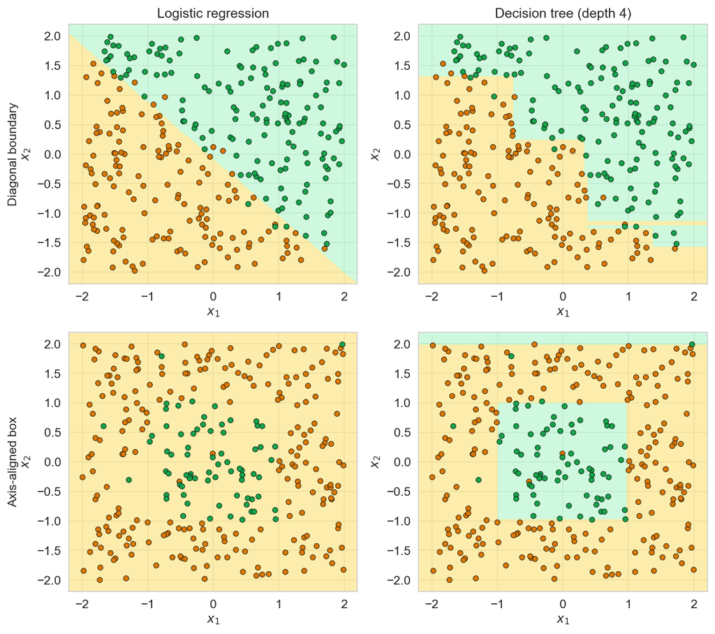

For each row (**diagonal boundary**, top; **axis-aligned box**, bottom), which model fits **better**, and why in 1 sentence each?

**TipSolution**

**Top row (diagonal):** **Logistic regression** wins. Its single linear boundary cuts cleanly along the diagonal; the depth-4 tree has to approximate the diagonal with a staircase of axis-aligned cuts and misclassifies points near the boundary.

The lesson: the **right model is a property of the data**, not a universal ranking. Linear models excel on smooth, monotone effects; trees excel on corners, thresholds, and interactions. On real data you don’t know the geometry — fit both and compare on held-out data.

**Question 9.** A random forest predicts **Airbnb nightly price** in NYC. The feature importance (MDI) bar chart:

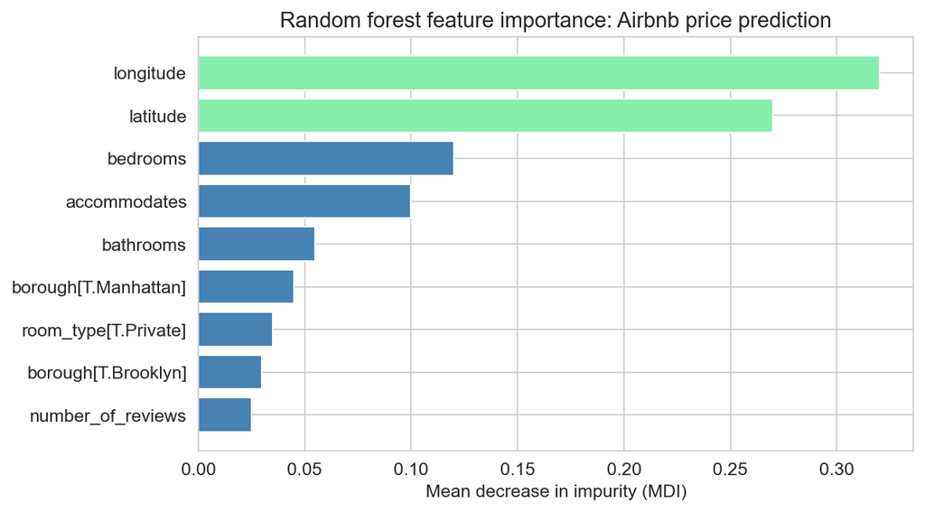

A real-estate blog reads this chart and writes: *“To raise an apartment’s price, the most effective interventions are (1) move it to a different latitude/longitude, and (2) add bedrooms.”*

1. What’s wrong with the blog’s interpretation? In 2 sentences, what does high MDI actually mean?
2. Suppose a host genuinely can add a bedroom (it’s intervenable). Does the MDI chart tell them how much price will go up? What tool from this course actually answers that question?

**TipSolution**

**(a)** **MDI is descriptive, not causal.** High MDI on a feature means the forest **uses that feature for splitting frequently and effectively** — the splits drop impurity a lot, *given the other features*. It does **not** mean intervening on the feature would change the outcome. (“Move your apartment” is also nonsense in the controllable sense — but even setting that aside, MDI just reflects model usage, not real-world causal effects.)

**(b)** No, MDI doesn’t tell the host the *magnitude* of price change from adding a bedroom. The tool that does is a **regression coefficient** (with appropriate controls): the coefficient on `bedrooms` from a multiple regression of price tells you, *controlling for the other features in the model*, how much the predicted price changes per added bedroom. Even this is an *association*, not a guaranteed causal effect — a properly randomized intervention (the gold standard of Ch 18) would be required to settle causality, since adding a bedroom usually changes other things (square footage, building stock, layout) simultaneously.

**Question 10.** A small bank trains a linear regression and a random forest to predict default rates as a function of one feature, `loan_size`. Training data lies in **$x \in [0, 10]$** (in $100K units, so loans of $0–$1M). Both models still produce predictions for inputs outside that range. The plot:

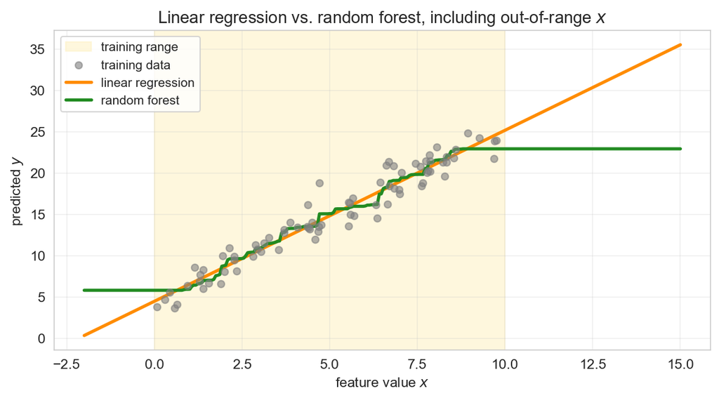

1. For $x = 15$ (a $1.5M loan, outside training range), the **random forest** outputs a flat prediction near 23. In 1–2 sentences, explain what the forest’s prediction *is* (in terms of training data) and why it is **flat** outside the training range.
2. Suppose the true underlying relationship really is linear and **continues at the same slope** past $x = 10$. Which model’s extrapolation at $x = 15$ is approximately right? Now suppose the true relationship **bends downward** past $x = 10$ (e.g., very large loans default at a lower rate because they go through extra underwriting). Which model is closer to the truth then? (1–2 sentences.)

**TipSolution**

**(a)** The forest’s prediction at $x = 15$ is the **average training-$y$ inside whichever leaf the input routes into** — here, the leaf containing the **largest training values** ($x$ near 10). Since no training row has $x > 10$, every input with $x > 10$ routes to the same boundary leaf, so the forest’s prediction is **constant** out there: it has no information about what happens at $x = 15$, and its prediction is bounded by the maximum training $y$.

**(b)** If the true relationship is **linear past $x = 10$**, the **linear model’s extrapolation is approximately right** (it extends the fitted slope); the forest’s flat prediction misses by a growing amount as $x$ grows.

If the true relationship **bends downward past $x = 10$**, the linear model **overshoots** (extends a slope that no longer applies) and the forest **undershoots** (flatlines at a value calibrated on the training range). **Neither is right**, but the forest happens to be closer if the true value at $x = 15$ is near the training-range maximum.

The deeper lesson: **forests cannot extrapolate** (their predictions are bounded by training outcomes), while **linear models extrapolate as if their fitted relationship continues forever**. Both are risky out-of-distribution; both call for distribution-shift monitoring and additional data before trusting the prediction.

**Question 11.** A classification tree is deciding whether to split a node containing 100 training examples: **60 customers who churned** (class 1) and **40 who stayed** (class 0). A candidate split on `tenure < 6 months` would partition the node into:

- **Left child** (`tenure < 6 months`): 50 churned, 10 stayed (60 customers)
- **Right child** (`tenure ≥ 6 months`): 10 churned, 30 stayed (40 customers)

Recall the **Gini impurity** for a binary node with class proportions $\hat p$ and $1 - \hat p$:
$$\text{Gini} = 2 \hat p (1 - \hat p).$$

1. Compute the Gini impurity of the **parent** node and of each **child** node. Show the arithmetic.
2. What Gini value indicates a **perfectly pure** node? Compute the **sample-weighted average** of the two children’s Gini values. Does this split reduce impurity below the parent?

**TipSolution**

**(a)** - **Parent** (60/100 = 0.6 churned, 0.4 stayed): $\text{Gini} = 2 \times 0.6 \times 0.4 = \mathbf{0.48}$. - **Left child** (50/60 ≈ 0.833 churned, 10/60 ≈ 0.167 stayed): $\text{Gini} = 2 \times \tfrac{50}{60} \times \tfrac{10}{60} = \tfrac{1000}{3600} \approx \mathbf{0.278}$. - **Right child** (10/40 = 0.25 churned, 30/40 = 0.75 stayed): $\text{Gini} = 2 \times 0.25 \times 0.75 = \mathbf{0.375}$.

**(b)** A **perfectly pure node has Gini = 0** (one class only, $\hat p \in \{0, 1\}$). The maximum for a binary node is $0.5$ (a 50/50 split).

Sample-weighted average of the children’s Gini values, weighting each child by its fraction of the parent’s samples:
$$\tfrac{60}{100} \times 0.278 + \tfrac{40}{100} \times 0.375 \approx 0.167 + 0.150 = \mathbf{0.317}.$$

The split **reduces impurity** from 0.48 (parent) to 0.317 (weighted child average), an impurity drop of about 0.16. This is the splitting criterion the tree maximizes at each node: pick the (feature, threshold) pair that drops weighted child impurity the most.